# COMPSCIX 415.2 Homework 5/Midterm

Dai_Zhechen

2019/3/2

```r
library(ggplot2)
library(tidyverse)
library(dplyr)
library(tibble)
```

## Git and Github (1.5 points)

My Github repository for my assignments can be found at this [MY URL](https://github.com/zhechendai/compscix-415-2-assignments)

## The tidyverse packages (3 points)

### 1. Can you name which package is associated with each task below?

#### Plotting -

`ggplot2`

#### Data munging/wrangling -

`dplyr`

#### Reshaping (speading and gathering) data -

`tidyr`

#### Importing/exporting data -

`readr`

### 2. Now can you name two functions that you’ve used `from each package` that you listed above for these tasks?

#### Plotting -

`aes()` - construct aesthetic mappings

`geom_smooth` - plot smoothed conditional means

#### Data munging/wrangling -

`select()` - take a subset of columns

`filter()` - take a subset of rows

#### Reshaping data -

`gather()` - gather columns into key-value pairs

`spread()` - spread a key-value pair across multiple columns.

#### Importing/exporting data -

`read_csv()` - to read a csv file

`write_csv()` - to write to a csv file

## R Basics (1.5 points)

### 1. Fix this code with the fewest number of changes possible so it works:

`My_data.name___is.too00ooLong! <- c( 1 , 2 , 3 )`

```r
My_data.name___is.too00ooLong <- c( 1 , 2 , 3 )
```

### 2. Fix this code so it works:

`my_string <- C('has', 'an', 'error', 'in', 'it)`

```r
my_string <- c('has', 'an', 'error', 'in', 'it')
```

### 3. Look at the code below and comment on what happened to the values in the vector.

```r
my_vector <- c(1, 2, '3', '4', 5)
my_vector
```

```
## [1] "1" "2" "3" "4" "5"
```

It doesn’t show error here since there is only one type of data appear, R won’t be confused.

## Data import/export (3 points)

### 1. Download the rail_trail.txt file from Canvas (in the Midterm Exam section) and successfully import it into R. Prove that it was imported successfully by including your import code and taking a glimpse of the result.

```r
file_path <- '/Users/jerryd/Desktop/JERRYGit/Midterm/rail_trail.txt'
txt_data <- read.delim2(file = '/Users/jerryd/Desktop/JERRYGit/Midterm/rail_trail.txt', sep = "|")
```

```r
glimpse(txt_data)
```

```
## Observations: 90
## Variables: 10
## $ hightemp   <int> 83, 73, 74, 95, 44, 69, 66, 66, 80, 79, 78, 65, 41, …
## $ lowtemp    <int> 50, 49, 52, 61, 52, 54, 39, 38, 55, 45, 55, 48, 49, …
## $ avgtemp    <fct> 66.5, 61, 63, 78, 48, 61.5, 52.5, 52, 67.5, 62, 66.5…
## $ spring     <int> 0, 0, 1, 0, 1, 1, 1, 1, 0, 0, 0, 1, 1, 0, 0, 1, 0, 1…
## $ summer     <int> 1, 1, 0, 1, 0, 0, 0, 0, 1, 1, 1, 0, 0, 0, 0, 0, 1, 0…
## $ fall       <int> 0, 0, 0, 0, 0, 0, 0, 0, 0, 0, 0, 0, 0, 1, 1, 0, 0, 0…
## $ cloudcover <fct> 7.59999990463257, 6.30000019073486, 7.5, 2.599999904…
## $ precip     <fct> 0, 0.28999999165535, 0.319999992847443, 0, 0.1400000…
## $ volume     <int> 501, 419, 397, 385, 200, 375, 417, 629, 533, 547, 43…
## $ weekday    <int> 1, 1, 1, 0, 1, 1, 1, 0, 0, 1, 1, 1, 1, 1, 1, 1, 0, 1…
```

### 2. Export the file into a comma-separated file and name it “rail_trail.csv”. Make sure you define the path correctly so that you know where it gets saved. Then reload the file. Include your export and import code and take another glimpse.

```r
write_csv(txt_data, path = '/Users/jerryd/Desktop/JERRYGit/Midterm/rail_trail.csv')
```

```r
file_path <- '/Users/jerryd/Desktop/JERRYGit/Midterm/rail_trail.csv'
csv_data <- read_csv(file = '/Users/jerryd/Desktop/JERRYGit/Midterm/rail_trail.csv')
```

```r
glimpse(csv_data)
```

```
## Observations: 90
## Variables: 10
## $ hightemp   <dbl> 83, 73, 74, 95, 44, 69, 66, 66, 80, 79, 78, 65, 41, …
## $ lowtemp    <dbl> 50, 49, 52, 61, 52, 54, 39, 38, 55, 45, 55, 48, 49, …
## $ avgtemp    <dbl> 66.5, 61.0, 63.0, 78.0, 48.0, 61.5, 52.5, 52.0, 67.5…
## $ spring     <dbl> 0, 0, 1, 0, 1, 1, 1, 1, 0, 0, 0, 1, 1, 0, 0, 1, 0, 1…
## $ summer     <dbl> 1, 1, 0, 1, 0, 0, 0, 0, 1, 1, 1, 0, 0, 0, 0, 0, 1, 0…
## $ fall       <dbl> 0, 0, 0, 0, 0, 0, 0, 0, 0, 0, 0, 0, 0, 1, 1, 0, 0, 0…
## $ cloudcover <dbl> 7.6, 6.3, 7.5, 2.6, 10.0, 6.6, 2.4, 0.0, 3.8, 4.1, 8…
## $ precip     <dbl> 0.00, 0.29, 0.32, 0.00, 0.14, 0.02, 0.00, 0.00, 0.00…
## $ volume     <dbl> 501, 419, 397, 385, 200, 375, 417, 629, 533, 547, 43…
## $ weekday    <dbl> 1, 1, 1, 0, 1, 1, 1, 0, 0, 1, 1, 1, 1, 1, 1, 1, 0, 1…
```

## Visualization (6 points)

### 2. Reproduce this graphic using the diamonds data set.

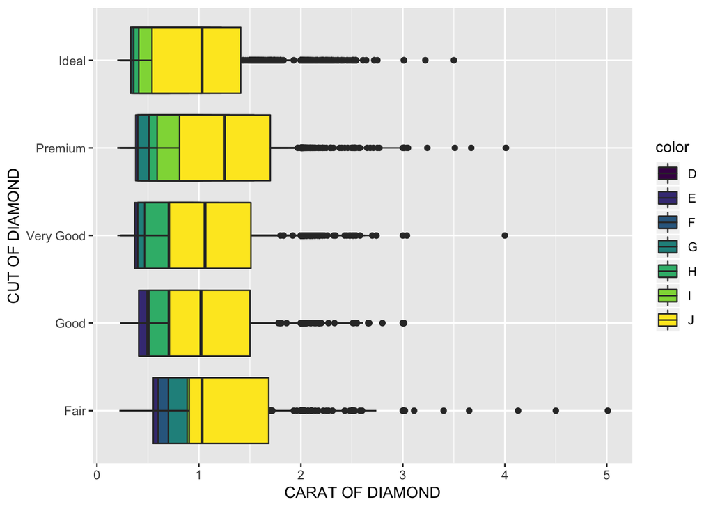

```r
ggplot(data = diamonds, mapping = aes(x = cut, y = carat)) +
  geom_boxplot(aes(fill = color), position = "identity") +
  coord_flip() +
  labs(x = "CUT OF DIAMOND", y = "CARAT OF DIAMOND")
```

### 3. The previous graphic is not very useful. We can make it much more useful by changing one thing about it. Make the change and plot it again.

In the previous graphic, the right part, y=3 to 5 si useless, so we can do zoom in.

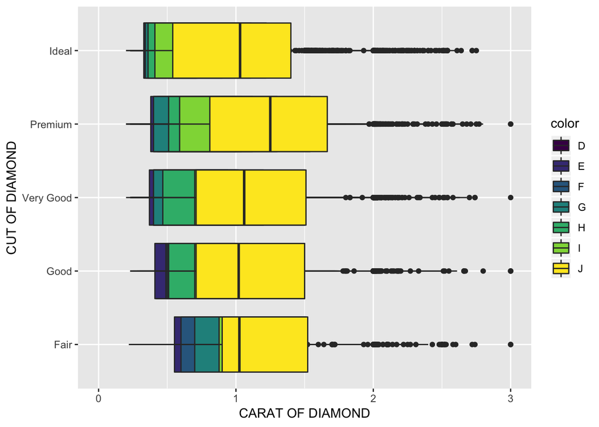

```r
ggplot(data = diamonds, mapping = aes(x = cut, y = carat)) +
  geom_boxplot(aes(fill = color), position = "identity") +
  coord_flip() + ylim(0,3) +
  labs(x = "CUT OF DIAMOND", y = "CARAT OF DIAMOND")
```

## Data munging and wrangling (6 points)

### 1. Is this data “tidy”? If yes, leave it alone and go to the next problem. If no, make it tidy. Note: this data set is called table2 and is available in the tidyverse package. It should be ready for you to use after you’ve loaded the tidyverse package.

```r
head(table2)
```

```
## # A tibble: 6 x 4
##   country      year type           count
##   <chr>       <int> <chr>          <int>
## 1 Afghanistan  1999 cases            745
## 2 Afghanistan  1999 population  19987071
## 3 Afghanistan  2000 cases           2666
## 4 Afghanistan  2000 population  20595360
## 5 Brazil       1999 cases          37737
## 6 Brazil       1999 population 172006362
```

This data is not tidy, cases and population should be cectors not values.

```r
spread(table2, key = type, value = count)
```

```
## # A tibble: 6 x 4
##   country      year  cases population
##   <chr>       <int>  <int>      <int>
## 1 Afghanistan  1999    745   19987071
## 2 Afghanistan  2000   2666   20595360
## 3 Brazil       1999  37737  172006362
## 4 Brazil       2000  80488  174504898
## 5 China        1999 212258 1272915272
## 6 China        2000 213766 1280428583
```

### 2. Create a new column in the diamonds data set called price_per_carat that shows the price of each diamond per carat (hint: divide). Only show me the code, not the output.

`diamonds <- mutate(diamonds, price_per_carat = price / carat)`

### 3. For each cut of diamond in the diamonds data set, how many diamonds, and what proportion, have a price > 10000 and a carat < 1.5? There are several ways to get to an answer, but your solution must use the data wrangling verbs from the tidyverse in order to get credit.

```r
diamonds %>% mutate(highcost = price > 10000, smallsize = carat < 1.5) %>%
  group_by(cut) %>% summarise(count = n(), fulfilled_Num = sum(smallsize & highcost), prop = (fulfilled_Num / count) * 100)
```

```
## # A tibble: 5 x 4
##   cut       count fulfilled_Num  prop
##   <ord>     <int>         <int> <dbl>
## 1 Fair       1610             4 0.248
## 2 Good       4906            17 0.347
## 3 Very Good 12082           155 1.28
## 4 Premium   13791           173 1.25
## 5 Ideal     21551           485 2.25
```

### • Do the results make sense? Why?

Yes, it is. When cut increses, the number of diamonds above $10000 price increases simultaneously which is expected.

### • Do we need to be wary of any of these numbers? Why?

Yes, we may do. Because it is unsual that such small diamonds will have the price which is above than $10000 even it is ideal cut, the data collection may have something wrong.

## EDA (6 points)

### Take a look at the txhousing data set that is included with the ggplot2 package and answer these questions:

```r
glimpse(txhousing)
```

```
## Observations: 8,602
## Variables: 9
## $ city      <chr> "Abilene", "Abilene", "Abilene", "Abilene", "Abilene"…
## $ year      <int> 2000, 2000, 2000, 2000, 2000, 2000, 2000, 2000, 2000,…
## $ month     <int> 1, 2, 3, 4, 5, 6, 7, 8, 9, 10, 11, 12, 1, 2, 3, 4, 5,…
## $ sales     <dbl> 72, 98, 130, 98, 141, 156, 152, 131, 104, 101, 100, 9…
## $ volume    <dbl> 5380000, 6505000, 9285000, 9730000, 10590000, 1391000…
## $ median    <dbl> 71400, 58700, 58100, 68600, 67300, 66900, 73500, 7500…
## $ listings  <dbl> 701, 746, 784, 785, 794, 780, 742, 765, 771, 764, 721…
## $ inventory <dbl> 6.3, 6.6, 6.8, 6.9, 6.8, 6.6, 6.2, 6.4, 6.5, 6.6, 6.2…
## $ date      <dbl> 2000.000, 2000.083, 2000.167, 2000.250, 2000.333, 200…
```

### 1. During what time period is this data from?

```r
summary(txhousing)
```

```
##      city                year          month            sales
##  Length:8602        Min.   :2000   Min.   : 1.000   Min.   :   6.0
##  Class :character   1st Qu.:2003   1st Qu.: 3.000   1st Qu.:  86.0
##  Mode  :character   Median :2007   Median : 6.000   Median : 169.0
##                     Mean   :2007   Mean   : 6.406   Mean   : 549.6
##                     3rd Qu.:2011   3rd Qu.: 9.000   3rd Qu.: 467.0
##                     Max.   :2015   Max.   :12.000   Max.   :8945.0
##                                                     NA's   :568
##      volume              median          listings       inventory
##  Min.   :8.350e+05   Min.   : 50000   Min.   :    0   Min.   : 0.000
##  1st Qu.:1.084e+07   1st Qu.:100000   1st Qu.:  682   1st Qu.: 4.900
##  Median :2.299e+07   Median :123800   Median : 1283   Median : 6.200
##  Mean   :1.069e+08   Mean   :128131   Mean   : 3217   Mean   : 7.175
##  3rd Qu.:7.512e+07   3rd Qu.:150000   3rd Qu.: 2954   3rd Qu.: 8.150
##  Max.   :2.568e+09   Max.   :304200   Max.   :43107   Max.   :55.900
##  NA's   :568         NA's   :616      NA's   :1424    NA's   :1467
##       date
##  Min.   :2000
##  1st Qu.:2004
##  Median :2008
##  Mean   :2008
##  3rd Qu.:2012
##  Max.   :2016
##
```

From 2000 to 2015.

### 2. How many cities are represented?

```r
count(txhousing, city)
```

```
## # A tibble: 46 x 2
##    city                      n
##    <chr>                 <int>
##  1 Abilene                 187
##  2 Amarillo                187
##  3 Arlington               187
##  4 Austin                  187
##  5 Bay Area                187
##  6 Beaumont                187
##  7 Brazoria County         187
##  8 Brownsville             187
##  9 Bryan-College Station   187
## 10 Collin County           187
## # … with 36 more rows
```

There are 46 cities.

### 3. Which city, month and year had the highest number of sales?

```r
arrange(txhousing, desc(sales))
```

```
## # A tibble: 8,602 x 9
##    city     year month sales     volume median listings inventory  date
##    <chr>   <int> <int> <dbl>      <dbl>  <dbl>    <dbl>     <dbl> <dbl>
##  1 Houston  2015     7  8945 2568156780 217600    23875       3.4 2016.
##  2 Houston  2006     6  8628 1795898108 155200    36281       5.6 2006.
##  3 Houston  2013     7  8468 2168720825 187800    21497       3.3 2014.
##  4 Houston  2015     6  8449 2490238594 222400    22311       3.2 2015.
##  5 Houston  2013     5  8439 2121508529 186100    20526       3.3 2013.
##  6 Houston  2014     6  8391 2342443127 211200    19725       2.9 2014.
##  7 Houston  2014     7  8391 2278932511 199700    20214       3   2014.
##  8 Houston  2014     8  8167 2195184825 202400    20007       2.9 2015.
##  9 Houston  2013     8  8155 2083377894 186700    21366       3.3 2014.
## 10 Houston  2006     5  8040 1602621368 151200    35398       5.5 2006.
## # … with 8,592 more rows
```

Houston, July, 2015

### 4. What kind of relationship do you think exists between the number of listings and the number of sales? Check your assumption and show your work.

Assumption: There is a positive relationship between the number of listings and the number of sales.

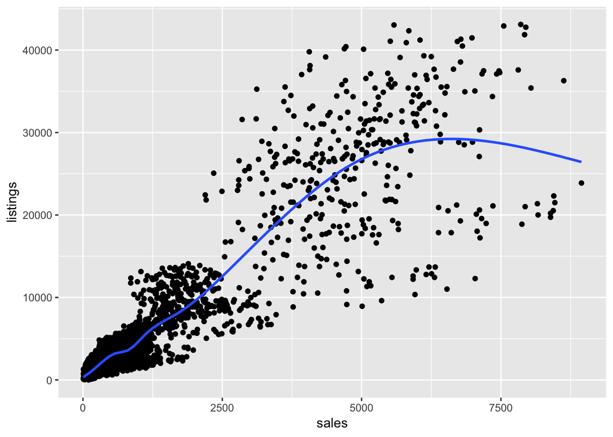

```r
ggplot(data = txhousing, mapping = aes(x = sales, y = listings)) +
  geom_point() +
  geom_smooth(se = FALSE)
```

### 5. What proportion of sales is missing for each city?

```r
txhousing %>%
  group_by(city) %>%
  summarise(count = n(), missing = sum(is.na(sales)), missing_prop = (missing / count) * 100)
```

```
## # A tibble: 46 x 4
##    city                  count missing missing_prop
##    <chr>                 <int>   <int>        <dbl>
##  1 Abilene                 187       0         0
##  2 Amarillo                187       0         0
##  3 Arlington               187       0         0
##  4 Austin                  187       0         0
##  5 Bay Area                187       0         0
##  6 Beaumont                187       0         0
##  7 Brazoria County         187      14         7.49
##  8 Brownsville             187       2         1.07
##  9 Bryan-College Station   187       0         0
## 10 Collin County           187       0         0
## # … with 36 more rows
```

### 6. Looking at only the cities and months with greater than 500 sales:

### • Are the distributions of the median sales price (column name median), when grouped by city, different? The same? Show your work.

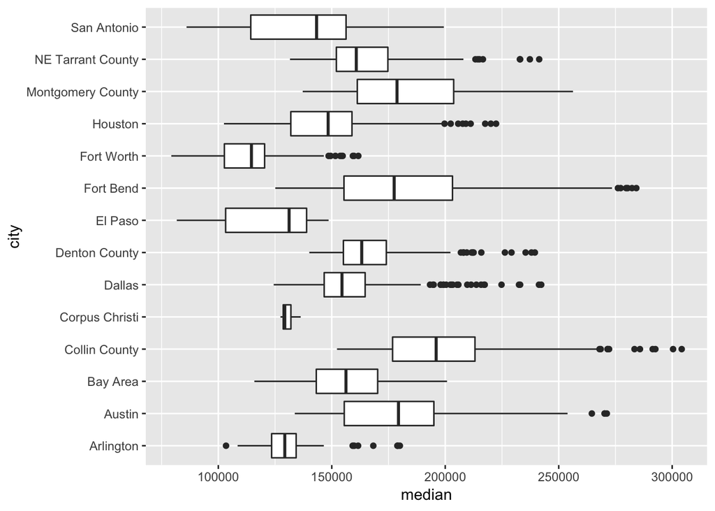

```r
greater_500 <- filter(txhousing, sales > 500)
ggplot(data = greater_500, mapping = aes(x = city, y = median)) +
  geom_boxplot() +
  coord_flip()
```

The distributions of the median sales price are different.

### • Any cities that stand out that you’d want to investigate further?

Corpus Christi. It has a very small range values, should collect more data.

### • Why might we want to filter out all cities and months with sales less than 500?

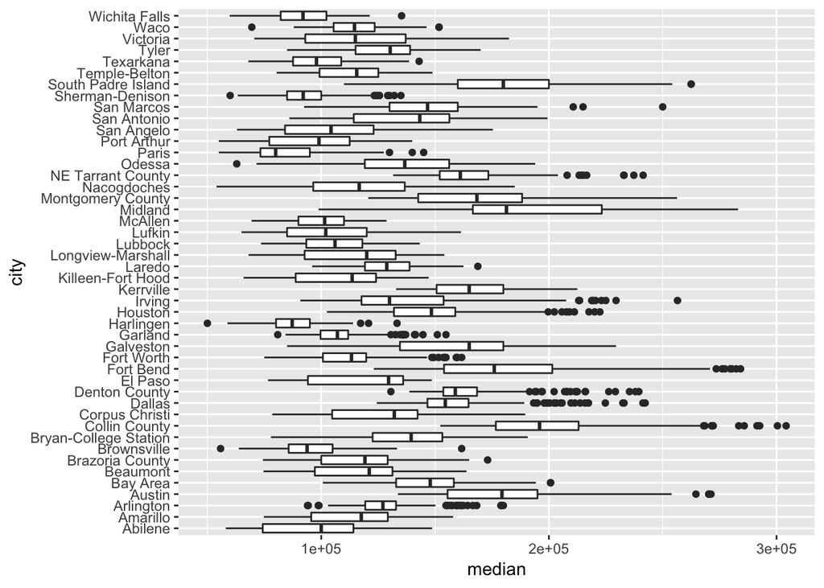

```r
ggplot(data = txhousing, mapping = aes(x = city, y = median)) +
  geom_boxplot() +
  coord_flip()
```

If we contains the cities and months with sales less than 500, the chart will become busy and noisy and analyze cities and months with sales less than 500 is meaningless.